# 510_Project_First_Draft

Hanna Lu

10/26/2020

### Survival Analysis

The aim of this study is to find significant factors that impact the mortality rate of critically ill patients within 90 days after they are discharged from the hospital. The findings of this study may help doctors to re-evaluate their discharge decisions to reduce the mortality rate.

This analysis uses variables from multiple data sets. Some of them are re-engineered. In addition to demographic and hospital stay information, comorbidity scores are also investigated in this study.

#### Data Source: https://mimic.physionet.org/gettingstarted/access/

Install packages:

```r
library(dplyr)
library(stringr)
library(reshape2)
library(comorbidity)
library(survival)
library(ggplot2)
```

### IMPORT NOTEEVENTS

A patient can have multiple reports (or doctor’s notes). We hypothesize that the more doctor’s notes, the higher the risk of mortality.But the number of reports is not readily available in the data set.

The following code creates a variable NUM_REPORTS (Number of Reports) from the NOTEEVENTS data set by grouping the data by HADM_ID (Hospital Admission ID) and then counting the number of rows in each group.

```r
filename <- gzfile('NOTEEVENTS.csv.gz','rt')
note <- read.csv(filename)

str(note)
```

```
## 'data.frame':    2083180 obs. of  11 variables:
##  $ ROW_ID     : int  174 175 176 177 178 179 180 181 182 183 ...
##  $ SUBJECT_ID : int  22532 13702 13702 13702 26880 53181 20646 42130 56174 56174 ...
##  $ HADM_ID    : int  167853 107527 167118 196489 135453 170490 134727 114236 163469 189681 ...
##  $ CHARTDATE  : chr  "2151-08-04" "2118-06-14" "2119-05-25" "2124-08-18" ...
##  $ CHARTTIME  : chr  "" "" "" "" ...
##  $ STORETIME  : chr  "" "" "" "" ...
##  $ CATEGORY   : chr  "Discharge summary" "Discharge summary" "Discharge summary" "Discharge summary" ...
##  $ DESCRIPTION: chr  "Report" "Report" "Report" "Report" ...
##  $ CGID       : int  NA NA NA NA NA NA NA NA NA NA ...
##  $ ISERROR    : int  NA NA NA NA NA NA NA NA NA NA ...
##  $ TEXT       : chr  "Admission Date:  [**2151-7-16**]       Discharge Date:  [**2151-8-4**]\n\n\nService:\nADDENDUM:\n\nRADIOLOGIC S"| __truncated__ "Admission Date:  [**2118-6-2**]       Discharge Date:  [**2118-6-14**]\n\nDate of Birth:                    Sex"| __truncated__ "Admission Date:  …
```

```r
# Create a data frame with 2 columns (HADM_ID and NUM_REPORTS) to be joined
# with other data sets
num_reports <- note %>%
  group_by(HADM_ID) %>%
  summarise(NUM_REPORTS = n(),.groups = 'drop') %>%
  select(HADM_ID, NUM_REPORTS)
```

### IMPORT ADMISSIONS

The ADMISSIONS data set contains some demographic information of the patients, as well as hospital admission and discharge information

The following code joins this data set with the Number of Reports data extracted from the NOTEEVENTS data set.

```r
filename <- gzfile('ADMISSIONS.csv.gz','rt')
admissions <- read.csv(filename)

str(admissions)
```

```
## 'data.frame':    58976 obs. of  19 variables:
##  $ ROW_ID              : int  21 22 23 24 25 26 27 28 29 30 ...
##  $ SUBJECT_ID          : int  22 23 23 24 25 26 27 28 30 31 ...
##  $ HADM_ID             : int  165315 152223 124321 161859 129635 197661 134931 162569 104557 128652 ...
##  $ ADMITTIME           : chr  "2196-04-09 12:26:00" "2153-09-03 07:15:00" "2157-10-18 19:34:00" "2139-06-06 16:14:00" ...
##  $ DISCHTIME           : chr  "2196-04-10 15:54:00" "2153-09-08 19:10:00" "2157-10-25 14:00:00" "2139-06-09 12:48:00" ...
##  $ DEATHTIME           : chr  "" "" "" "" ...
##  $ ADMISSION_TYPE      : chr  "EMERGENCY" "ELECTIVE" "EMERGENCY" "EMERGENCY" ...
##  $ ADMISSION_LOCATION  : chr  "EMERGENCY ROOM ADMIT" "PHYS REFERRAL/NORMAL DELI" "TRANSFER FROM HOSP/EXTRAM" "TRANSFER FROM HOSP/EXTRAM" ...
##  $ DISCHARGE_LOCATION  : chr  "DISC-TRAN CANCER/CHLDRN H" "HOME HEALTH CARE" "HOME HEALTH CARE" "HOME" ...
##  $ INSURANCE           : chr  "Private" "Medicare" "Medicare" "Private" ...
##  $ LANGUAGE            : chr  "" "" "ENGL" "" ...
##  $ RELIGION            : chr  "UNOBTAINABLE" "CATHOLIC" "CATHOLIC" "PROTESTANT QUAKER" ...
##  $ MARITAL_STATUS      : chr  "MARRIED" "MARRIED" "MARRIED" "SINGLE" ...
##  $ ETHNICITY           : chr  "WHITE" "WHITE" "WHITE" "WHITE" ...
##  $ EDREGTIME           : chr  "2196-04-09 10:06:00" "" "" "" ...
##  $ EDOUTTIME           : chr  "2196-04-09 13:24:00" "" "" "" ...
##  $ DIAGNOSIS           : chr  "BENZODIAZEPINE OVERDOSE" "CORONARY ARTERY DISEASE\\CORONARY ARTERY BYPASS GRAFT/SDA" "BRAIN MASS" "INTERIOR MYOCARDIAL INFARCTION" ...
##  $ HOSPITAL_EXPIRE_FLAG: int  0 0 0 0 0 0 0 0 0 1 ...
##  $ HAS_CHARTEVENTS_DATA: int  1 1 1 1 1 1 1 1 1 1 ...
```

```r
# Merge admissions and num_reports (inner join):
adm = merge(admissions, num_reports, by='HADM_ID')
```

### IMPORT ICUSTAYS

This data set contains the ICU stay information such as the first and last ICU unit the patient stayed in, in and out time, and length of stay.

A patient can be admitted to different ICU units during their stay in the hospital. We hypothesize that the last ICU unit the patient stayed in may be related to the patient’s risk of mortality since it carries the information about the patient’s latest condition. ICU length of stay may have an impact on the mortality risk as well.

```r
filename <- gzfile('ICUSTAYS.csv.gz','rt')
icu <- read.csv(filename)

str(icu)
```

```
## 'data.frame':    61532 obs. of  12 variables:
##  $ ROW_ID        : int  365 366 367 368 369 370 371 372 373 374 ...
##  $ SUBJECT_ID    : int  268 269 270 271 272 273 274 275 276 277 ...
##  $ HADM_ID       : int  110404 106296 188028 173727 164716 158689 130546 129886 135156 171601 ...
##  $ ICUSTAY_ID    : int  280836 206613 220345 249196 210407 241507 254851 219649 206327 272866 ...
##  $ DBSOURCE      : chr  "carevue" "carevue" "carevue" "carevue" ...
##  $ FIRST_CAREUNIT: chr  "MICU" "MICU" "CCU" "MICU" ...
##  $ LAST_CAREUNIT : chr  "MICU" "MICU" "CCU" "SICU" ...
##  $ FIRST_WARDID  : int  52 52 57 52 57 52 12 7 57 56 ...
##  $ LAST_WARDID   : int  52 52 57 23 57 52 12 7 57 56 ...
##  $ INTIME        : chr  "2198-02-14 23:27:38" "2170-11-05 11:05:29" "2128-06-24 15:05:20" "2120-08-07 23:12:42" ...
##  $ OUTTIME       : chr  "2198-02-18 05:26:11" "2170-11-08 17:46:57" "2128-06-27 12:32:29" "2120-08-10 00:39:04" ...
##  $ LOS           : num  3.25 3.28 2.89 2.06 1.62 ...
```

```r
# Create two columns for the last ICU unit and total Length of Stay:
icu_last <- icu %>%
  select(HADM_ID, LAST_CAREUNIT, LOS) %>%
  group_by(HADM_ID) %>%
  mutate(LAST_ICU = last(LAST_CAREUNIT)) %>%
  select(HADM_ID, LAST_ICU) %>%
  distinct()

# Merge ICU Unit data with admission data (inner join):
adm_icu <- merge(adm, icu_last, by = 'HADM_ID')
```

### IMPORT PATIENTS

This data set contains patients’ personal information such as gender, date of birth, and date of death. We need the date of birth variable to calculate the patients’ age, and the date of death variable to create the EVENT column (weather of not a death event occurred) and the Duration column (length of time until a death event occurred) for the survival analysis.

The following code joins this data set with the previous data set.

```r
filename <- gzfile('PATIENTS.csv.gz','rt')
patients <- read.csv(filename)

str(patients)
```

```
## 'data.frame':    46520 obs. of  8 variables:
##  $ ROW_ID     : int  234 235 236 237 238 239 240 241 242 243 ...
##  $ SUBJECT_ID : int  249 250 251 252 253 255 256 257 258 260 ...
##  $ GENDER     : chr  "F" "F" "M" "M" ...
##  $ DOB        : chr  "2075-03-13 00:00:00" "2164-12-27 00:00:00" "2090-03-15 00:00:00" "2078-03-06 00:00:00" ...
##  $ DOD        : chr  "" "2188-11-22 00:00:00" "" "" ...
##  $ DOD_HOSP   : chr  "" "2188-11-22 00:00:00" "" "" ...
##  $ DOD_SSN    : chr  "" "" "" "" ...
##  $ EXPIRE_FLAG: int  0 1 0 0 0 0 0 1 0 0 ...
```

```r
# Merge patients and adm_icu:
df_patient_icu <- merge(adm_icu, patients, by='SUBJECT_ID', all.x = T)
```

### IMPORT DIAGNOSES_ICD

This data set contains the ICD9_CODE (code for type of diagnosed disease) for each patient. A patient can have multiple ICD9 codes

```r
filename <- gzfile('DIAGNOSES_ICD.csv.gz','rt')
diagnoses <- read.csv(filename)

diagnoses <- diagnoses[,c("HADM_ID","ICD9_CODE")]

df_com <- merge(df_patient_icu, diagnoses, by = 'HADM_ID', all.x = T)
```

### COMORBIDITY SCORES

```r
# Charlson comorbidity scores based on ICD-10 diagnostic codes:
df_comorbidity <- comorbidity(x = df_com, id = "HADM_ID", code = "ICD9_CODE",
                             score = "charlson", assign0 = FALSE, icd = 'icd9')

# Remove the last four items from the comorbidity output
df_comorbidity <- df_comorbidity[,!names(df_comorbidity) %in%
                                   c("score", "index","wscore","windex")]

# Remove the icd code column from original data frame:
com_no_icd <- df_com[,names(df_com) != 'ICD9_CODE']

# Remove duplicates from original data frame:
unique_com <- unique(com_no_icd)

# Merge the main dataset and the comorbidity:
com_all <- merge(unique_com, df_comorbidity, by="HADM_ID")

# Remove "DIAGNOSIS":
com_all <- select(com_all, -DIAGNOSIS)
```

### DATA CLEANING

The following code generates the EVENT column (whether or not a patient died within 90 days of discharge from hospital) and the Duration column (time difference between Date of Death and Date of Discharge if the patient died during the following up period. If Date of Death is missing, set it as 300 days)

The following code also removes the patients who are admitted to the hospital as “NEWBORN”, or died within one day after discharge, or died in the hospital.

```r
# Convert DOD (Date of Death) to date format:
com_all$DOD <- as.Date(com_all$DOD, format = '%Y-%m-%d')

df_all <- com_all %>%
  # Identify DODs after 90 days and create Duration column
  mutate(Duration = ifelse(is.na(DOD), 300,
                           (DOD - as.Date(DISCHTIME, format = '%Y-%m-%d %H:%M:%S')))) %>%
  # Create EVENT (death within 90 days of discharge as 1, otherwise 0)
  mutate(EVENT = ifelse(Duration <= 90, 1, 0)) %>%
  # Remove patients who died before discharge or within one day of discharge
  # Remove newborns
  # Remove patients who died in hospital
  filter(Duration >= 1 & ADMISSION_TYPE!='NEWBORN' & HOSPITAL_EXPIRE_FLAG == 0)
```

The following code creates the HOSPITAL_LOS (Hospital Length of Stay, which is time between admission and discharge) and Age(age at time of discharge) columns. It also removes the patients who stayed in the hospital for less than one day, who are under the age of 18, and those who are discharged to hospice.

```r
df_all <- df_all %>%
  # Create a column for hospital length of stay
  mutate(HOSPITAL_LOS = (as.Date(DISCHTIME, format = '%Y-%m-%d %H:%M:%S') -
                           as.Date(ADMITTIME, format = '%Y-%m-%d %H:%M:%S'))) %>%
  # Remove those who stayed less than 1 day in the hospital
  filter(HOSPITAL_LOS > 1) %>%
  # Create Age at Discharge column from DOB and Discharge time columns
  mutate(age = (as.Date(DISCHTIME, format = '%Y-%m-%d %H:%M:%S') -
                  as.Date(DOB, format = '%Y-%m-%d %H:%M:%S'))/365) %>%
  # Remove those who are under the age of 18:
  filter(age >= 18) %>%
  # Remove those that were discharged to hospice related locations
  filter(DISCHARGE_LOCATION != 'HOSPICE')

# If age is greater than 100, code it to 90
# In the MIMIC database, patients older than 89 were coded as 300 years old
df_all$age <- ifelse(df_all$age > 100, 90, round(df_all$age,1))
```

```r
# Regroup Marital Status:
df_all <- df_all %>%
  mutate(MARITAL_STATUS_CAT = case_when(
          MARITAL_STATUS == 'SINGLE'                       ~ 'SINGLE',
          MARITAL_STATUS == 'WIDOWED'                      ~ 'WIDOWED',
          MARITAL_STATUS %in% c('MARRIED', 'LIFE PARTNER') ~ 'MARRIED',
          MARITAL_STATUS %in% c('DIVORCED','SEPARATED')    ~ 'DIVORCED',
          TRUE                                             ~ 'UNKNOWN'))

df_all$MARITAL_STATUS_CAT <- factor(df_all$MARITAL_STATUS_CAT,
                                    levels = c("MARRIED","SINGLE","DIVORCED",
                                       "WIDOWED", "UNKNOWN"))

# Regroup Ethnicity:
df_all <- df_all %>%
  mutate(ETHNICITY_CAT = case_when(
    str_detect(ETHNICITY, 'WHITE')                               ~ 'WHITE',
    str_detect(ETHNICITY, 'BLACK')                               ~ 'BLACK',
    str_detect(ETHNICITY, 'HISPANIC')                            ~ 'HISPANIC',
    str_detect(ETHNICITY, 'ASIAN')                               ~ 'ASIAN',
    ETHNICITY %in% c('UNKNOWN/NOT SPECIFIED','UNABLE TO OBTAIN',
                     'PATIENT DECLINED TO ANSWER')               ~ 'UNKNOWN',
    TRUE                                                         ~ 'OTHER'))

df_all$ETHNICITY_CAT <- factor(df_all$ETHNICITY_CAT,
                               levels = c("WHITE","BLACK","HISPANIC","ASIAN",
                                          "OTHER","UNKNOWN"))

# Discharge Location:
df_all <- df_all %>%
  mutate(DISCH_LOC_CAT = case_when(
    str_detect(DISCHARGE_LOCATION, 'SNF')            ~ 'SNF',
    DISCHARGE_LOCATION %in% c('HOME HEALTH CARE',
                      'HOME WITH HOME IV PROVIDER')  ~ 'HOME HEALTH CARE',
    DISCHARGE_LOCATION == 'HOME'                     ~ 'HOME',
    DISCHARGE_LOCATION == 'LONG TERM CARE HOSPITAL'  ~ 'LONG TERM CARE HOSPITAL',
    DISCHARGE_LOCATION == 'REHAB/DISTINCT PART HOSP' ~ 'REHAB/DISTINCT PART HOSP',
    TRUE                                             ~ 'OTHER'))

df_all$DISCH_LOC_CAT <- factor(df_all$DISCH_LOC_CAT,
                               levels = c("HOME","HOME HEALTH CARE",
                                          "LONG TERM CARE HOSPITAL",
                                          "REHAB/DISTINCT PART HOSP",
                                          "SNF","OTHER"))
```

The following code makes numerical variables into categorical.

```r
# Impute the NUM_REPORTS column with 0 where Num_reports is missing
df_all$NUM_REPORTS <- ifelse(is.na(df_all$NUM_REPORTS), 0, df_all$NUM_REPORTS)

# Make numerical variables into bins:
df_all <- within(df_all,{
  # Bin Hospital Length of Stay:
  HOSPITAL_LOS_CAT <- cut(as.numeric(HOSPITAL_LOS), breaks=c(-Inf,5,10,20,Inf),
                         labels = c("<=5","6-10","11-20",">20"))
  # Bin Number of Reports:
  NUM_REPORTS_CAT <- cut(NUM_REPORTS, breaks=c(-Inf,10,20,50, Inf),
                        labels = c("<=10","11-20", "21-50", ">50"))
  # Bin Age according to MeSH:
  AGE_CAT <- cut(round(age), breaks=c(-Inf,44,64,79, Inf),
                labels = c("<=44","45-64", "65-79", ">=80"))
})

# Reorder the levels of the new categorical variables:
df_all$HOSPITAL_LOS_CAT = factor(df_all$HOSPITAL_LOS_CAT,
                                 levels = c("<=5","6-10","11-20",">20"))

df_all$NUM_REPORTS_CAT = factor(df_all$NUM_REPORTS_CAT,
                                levels = c("<=10","11-20", "21-50", ">50" ))

df_all$AGE_CAT = factor(df_all$AGE_CAT,
                        levels = c("<=44", "45-64", "65-79", ">=80"))
```

### DATA VISUALIZATION

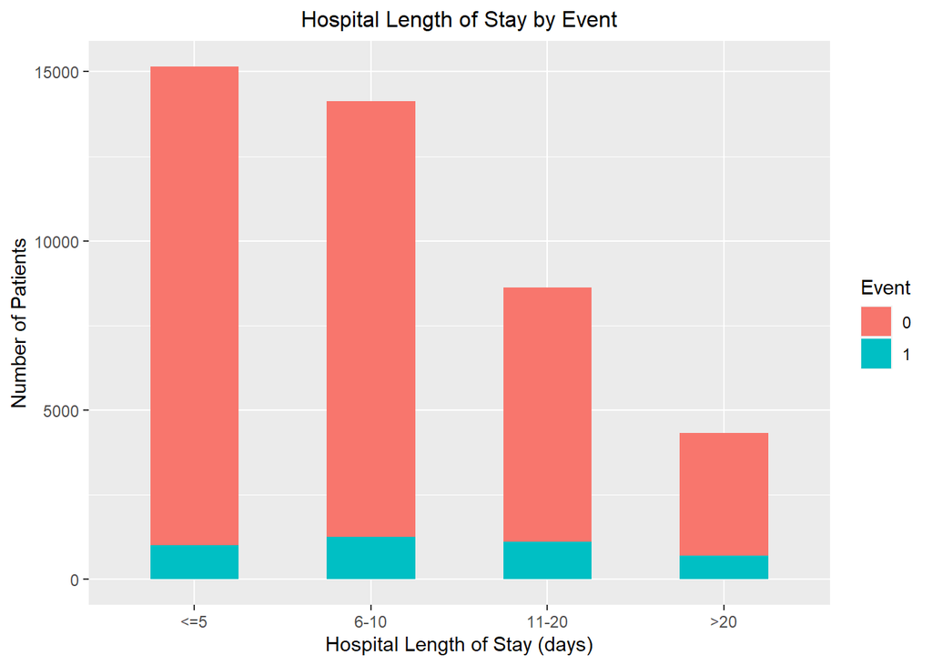

```r
# Plot of Hospital Length of Stay vs Event
ggplot(df_all) +
  geom_bar(aes(x = HOSPITAL_LOS_CAT, fill = factor(EVENT)),width = 0.5) +
  ggtitle('Hospital Length of Stay by Event') +
  theme(plot.title = element_text(hjust = 0.5, size = 12)) +
  labs(x = 'Hospital Length of Stay (days)', y = 'Number of Patients',
       fill = 'Event')
```

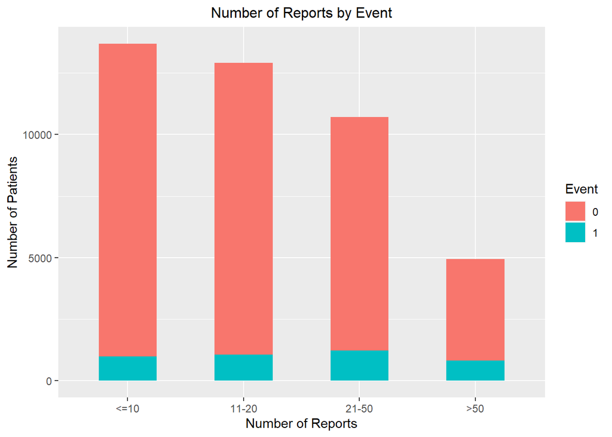

```r
# Plot of Number of Reports by Event
ggplot(df_all) +
  geom_bar(aes(x = NUM_REPORTS_CAT, fill = factor(EVENT)), width = 0.5) +
  ggtitle('Number of Reports by Event') +
  theme(plot.title = element_text(hjust = 0.5, size = 12)) +
  scale_color_discrete(name = 'Event') +
  labs(x = 'Number of Reports', y = 'Number of Patients', fill = 'Event')
```

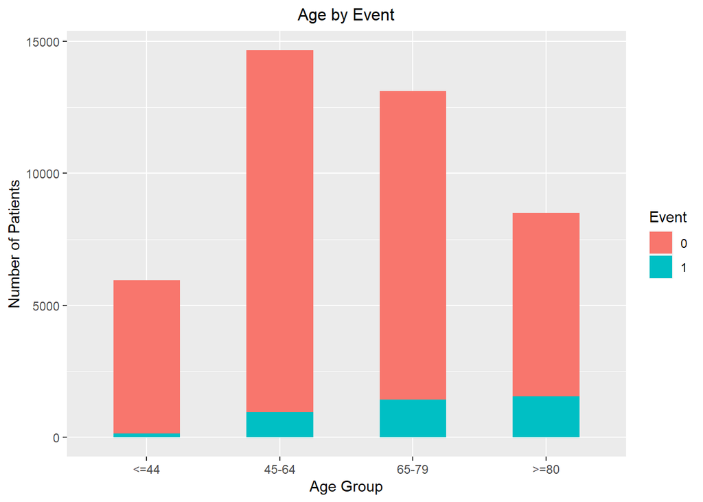

```r
# Plot of Age by Event
ggplot(df_all) +
  geom_bar(aes(x = AGE_CAT, fill = factor(EVENT)), width = 0.5) +
  ggtitle('Age by Event') +
  theme(plot.title = element_text(hjust = 0.5, size = 12)) +
  scale_color_discrete(name = 'Event') +
  labs(x = 'Age Group', y = 'Number of Patients', fill = 'Event')
```

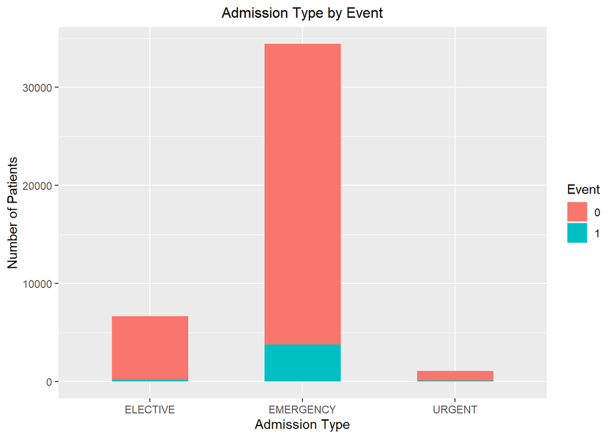

```r
# Plot of Admission Type by Event
ggplot(df_all) +
  geom_bar(aes(x = ADMISSION_TYPE, fill = factor(EVENT)), width = 0.5) +
  ggtitle('Admission Type by Event') +
  theme(plot.title = element_text(hjust = 0.5, size = 12)) +
  scale_color_discrete(name = 'Event') +
  labs(x = 'Admission Type', y = 'Number of Patients', fill = 'Event')
```

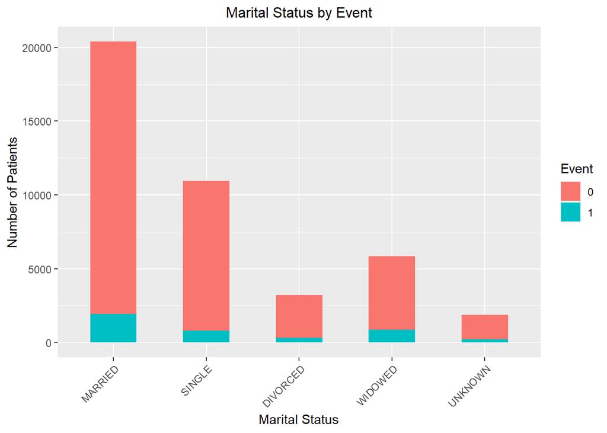

```r
# Plot of MARITAL_STATUS_CAT by Event
ggplot(df_all) +
  geom_bar(aes(x = MARITAL_STATUS_CAT, fill = factor(EVENT)), width = 0.5) +
  ggtitle('Marital Status by Event') +
  theme(plot.title = element_text(hjust = 0.5, size = 12),
        axis.text.x = element_text(angle = 45, vjust=1, hjust=1)) +
  scale_color_discrete(name = 'Event') +
  labs(x = 'Marital Status', y = 'Number of Patients', fill = 'Event')
```

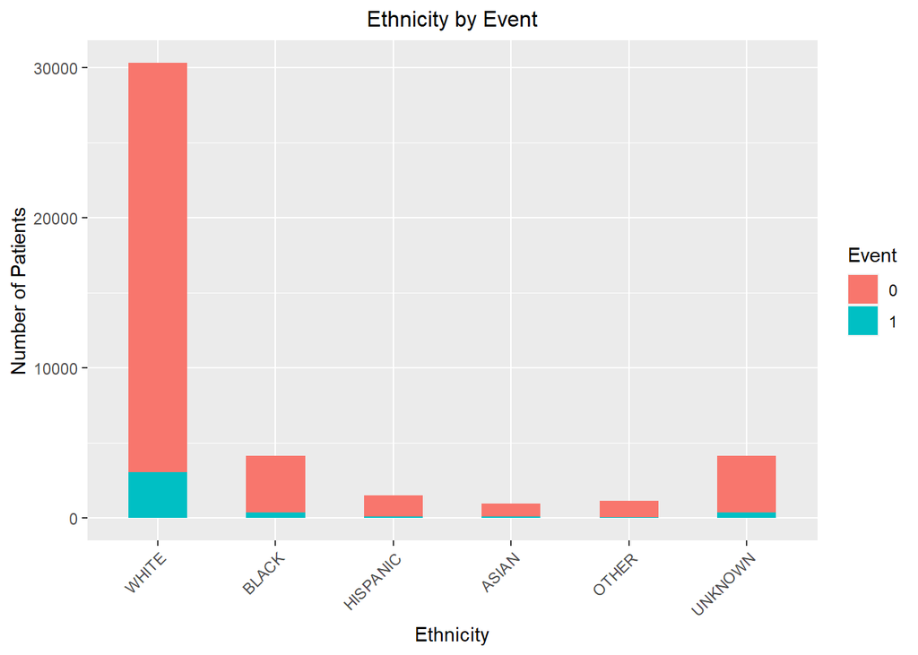

```r
# Plot of MARITAL_STATUS_CAT by Event
ggplot(df_all) +
  geom_bar(aes(x = ETHNICITY_CAT, fill = factor(EVENT)), width = 0.5) +
  ggtitle('Ethnicity by Event') +
  theme(plot.title = element_text(hjust = 0.5, size = 12),
        axis.text.x = element_text(angle = 45, vjust=1, hjust=1)) +
  scale_color_discrete(name = 'Event') +
  labs(x = 'Ethnicity', y = 'Number of Patients', fill = 'Event')
```

The following code removes the variables that are no longer in use to release memory:

```r
rm(adm, adm_icu, admissions, df_com, df3, diagnoses, icu, icu_last,
   num_reports, patients, df_adults)
```

### SURVIVAL ANALYSIS

```r
# Select columns that will be used in the model:
all <- df_all %>%
  select("HADM_ID","ADMISSION_TYPE","LAST_ICU", "GENDER",
         "ami","chf","pvd","cevd","dementia","copd","rheumd","pud","mld",
         "diab","diabwc" ,"hp", "rend","canc","msld","metacanc","aids",
         "Duration", "EVENT","MARITAL_STATUS_CAT", "ETHNICITY_CAT",
         "AGE_CAT","NUM_REPORTS_CAT","HOSPITAL_LOS_CAT")
```

The following code performs the Cox Proportional Hazard survival analysis:

```r
time <- all$Duration
event <- all$EVENT
x <- subset(all, select = -c(HADM_ID, Duration, EVENT))

coxph <- coxph(Surv(time,event) ~ ., data = x)
summary(coxph)
```

```
## Call:
## coxph(formula = Surv(time, event) ~ ., data = x)
##
##   n= 42232, number of events= 4101
##
##                                coef exp(coef) se(coef)       z Pr(>|z|)
## ADMISSION_TYPEEMERGENCY     1.02876   2.79761  0.07536  13.651  < 2e-16 ***
## ADMISSION_TYPEURGENT        0.89122   2.43809  0.12613   7.066 1.60e-12 ***
## LAST_ICUCSRU               -0.79170   0.45308  0.07421 -10.669  < 2e-16 ***
## LAST_ICUMICU                0.24027   1.27159  0.04855   4.949 7.46e-07 ***
## LAST_ICUSICU               -0.13788   0.87120  0.06116  -2.255 0.024160 *
## LAST_ICUTSICU              -0.33396   0.71609  0.07557  -4.419 9.91e-06 ***
## GENDERM                     0.09437   1.09897  0.03364   2.805 0.005027 **
## ami                        -0.09707   0.90749  0.04431  -2.190 0.028491 *
## chf                         0.35976   1.43298  0.03613   9.956  < 2e-16 ***
## pvd                         0.17422   1.19032  0.05012   3.476 0.000509 ***
## cevd                        0.14548   1.15659  0.04846   3.002 0.002683 **
## dementia                    0.51119   1.66727  0.08119   6.297 3.04e-10 ***
## copd                        0.10636   1.11222  0.03528   3.015 0.002573 **
## rheumd                     -0.03776   0.96295  0.09334  -0.404 0.685850
## pud                        -0.17681   0.83794  0.09259  -1.910 0.056185 .
## mld                         0.22085   1.24714  0.06387   3.458 0.000544 ***
## diab                        0.01255   1.01263  0.03718   0.337 0.735789
## diabwc                      0.07734   1.08041  0.06418   1.205 0.228213
## hp                          0.53158   1.70161  0.08118   6.548 5.82e-11 ***
## rend                        0.30483   1.35640  0.03910   7.796 6.40e-15 ***
## canc                        0.60472   1.83073  0.04413  13.703  < 2e-16 ***
## msld                        0.67307   1.96025  0.08407   8.006 1.19e-15 ***
## metacanc                    1.45524   4.28552  0.04861  29.936  < 2e-16 ***
## aids                        0.66163   1.93795  0.13717   4.823 1.41e-06 ***
## MARITAL_STATUS_CATSINGLE   -0.04814   0.95300  0.04415  -1.090 0.275555
## MARITAL_STATUS_CATDIVORCED  0.14938   1.16111  0.06239   2.394 0.016646 *
## MARITAL_STATUS_CATWIDOWED   0.03372   1.03429  0.04539   0.743 0.457633
## MARITAL_STATUS_CATUNKNOWN   0.25427   1.28952  0.07480   3.399 0.000675 ***
## ETHNICITY_CATBLACK         -0.11383   0.89241  0.05670  -2.008 0.044690 *
## ETHNICITY_CATHISPANIC      -0.07919   0.92386  0.09792  -0.809 0.418677
## ETHNICITY_CATASIAN         -0.15279   0.85831  0.10389  -1.471 0.141389
## ETHNICITY_CATOTHER         -0.25854   0.77218  0.11888  -2.175 0.029652 *
## ETHNICITY_CATUNKNOWN        0.20880   1.23219  0.05742   3.636 0.000277 ***
## AGE_CAT45-64                0.74375   2.10380  0.09003   8.261  < 2e-16 ***
```

[output cut: 44 more lines]

```
## ETHNICITY_CATUNKNOWN          1.2322     0.8116    1.1010    1.3790
## AGE_CAT45-64                  2.1038     0.4753    1.7635    2.5098
## AGE_CAT65-79                  3.6232     0.2760    3.0350    4.3253
## AGE_CAT>=80                   6.2207     0.1608    5.1919    7.4535
## NUM_REPORTS_CAT11-20          1.0680     0.9363    0.9764    1.1681
## NUM_REPORTS_CAT21-50          1.1992     0.8339    1.0946    1.3139
## NUM_REPORTS_CAT>50            1.5302     0.6535    1.3696    1.7095
## HOSPITAL_LOS_CAT6-10          1.1616     0.8608    1.0658    1.2661
## HOSPITAL_LOS_CAT11-20         1.5004     0.6665    1.3638    1.6506
## HOSPITAL_LOS_CAT>20           1.8514     0.5401    1.6480    2.0799
##
## Concordance= 0.795  (se = 0.003 )
## Likelihood ratio test= 4734  on 42 df,   p=<2e-16
## Wald test            = 4667  on 42 df,   p=<2e-16
## Score (logrank) test = 5566  on 42 df,   p=<2e-16
```

```r
x <- select(x, -c(diab,pud,rheumd,diabwc))

coxph <- coxph(Surv(time,event) ~ ., data = x)
summary(coxph)
```

```
## Call:
## coxph(formula = Surv(time, event) ~ ., data = x)
##
##   n= 42232, number of events= 4101
##
##                                coef exp(coef) se(coef)       z Pr(>|z|)
## ADMISSION_TYPEEMERGENCY     1.02557   2.78870  0.07535  13.611  < 2e-16 ***
## ADMISSION_TYPEURGENT        0.88631   2.42616  0.12610   7.029 2.08e-12 ***
## LAST_ICUCSRU               -0.79052   0.45361  0.07421 -10.652  < 2e-16 ***
## LAST_ICUMICU                0.23750   1.26808  0.04849   4.898 9.70e-07 ***
## LAST_ICUSICU               -0.13860   0.87057  0.06114  -2.267 0.023393 *
## LAST_ICUTSICU              -0.33399   0.71606  0.07557  -4.420 9.89e-06 ***
## GENDERM                     0.09344   1.09795  0.03349   2.790 0.005268 **
## ami                        -0.09457   0.90976  0.04425  -2.137 0.032580 *
## chf                         0.36517   1.44076  0.03599  10.146  < 2e-16 ***
## pvd                         0.17752   1.19426  0.04985   3.561 0.000369 ***
## cevd                        0.14756   1.15900  0.04843   3.047 0.002311 **
## dementia                    0.50923   1.66402  0.08118   6.273 3.54e-10 ***
## copd                        0.10665   1.11254  0.03523   3.027 0.002468 **
## mld                         0.21873   1.24450  0.06383   3.427 0.000611 ***
## hp                          0.52842   1.69626  0.08112   6.514 7.31e-11 ***
## rend                        0.31527   1.37063  0.03800   8.298  < 2e-16 ***
## canc                        0.60223   1.82619  0.04410  13.657  < 2e-16 ***
## msld                        0.67037   1.95497  0.08402   7.978 1.48e-15 ***
## metacanc                    1.45299   4.27587  0.04856  29.924  < 2e-16 ***
## aids                        0.65743   1.92983  0.13703   4.798 1.60e-06 ***
## MARITAL_STATUS_CATSINGLE   -0.04789   0.95324  0.04415  -1.085 0.278054
## MARITAL_STATUS_CATDIVORCED  0.15162   1.16371  0.06237   2.431 0.015056 *
## MARITAL_STATUS_CATWIDOWED   0.03354   1.03411  0.04537   0.739 0.459722
## MARITAL_STATUS_CATUNKNOWN   0.25502   1.29049  0.07478   3.410 0.000649 ***
## ETHNICITY_CATBLACK         -0.11040   0.89548  0.05642  -1.957 0.050373 .
## ETHNICITY_CATHISPANIC      -0.07574   0.92706  0.09779  -0.774 0.438646
## ETHNICITY_CATASIAN         -0.15622   0.85537  0.10377  -1.506 0.132195
## ETHNICITY_CATOTHER         -0.25738   0.77307  0.11888  -2.165 0.030379 *
## ETHNICITY_CATUNKNOWN        0.20847   1.23179  0.05742   3.631 0.000282 ***
## AGE_CAT45-64                0.74389   2.10411  0.08995   8.270  < 2e-16 ***
## AGE_CAT65-79                1.28482   3.61402  0.09020  14.245  < 2e-16 ***
## AGE_CAT>=80                 1.81762   6.15720  0.09206  19.744  < 2e-16 ***
## NUM_REPORTS_CAT11-20        0.06799   1.07036  0.04571   1.488 0.136882
## NUM_REPORTS_CAT21-50        0.18284   1.20062  0.04658   3.925 8.67e-05 ***
```

[output cut: 36 more lines]

```
## ETHNICITY_CATUNKNOWN          1.2318     0.8118    1.1007    1.3785
## AGE_CAT45-64                  2.1041     0.4753    1.7640    2.5098
## AGE_CAT65-79                  3.6140     0.2767    3.0284    4.3129
## AGE_CAT>=80                   6.1572     0.1624    5.1407    7.3747
## NUM_REPORTS_CAT11-20          1.0704     0.9343    0.9786    1.1707
## NUM_REPORTS_CAT21-50          1.2006     0.8329    1.0959    1.3154
## NUM_REPORTS_CAT>50            1.5323     0.6526    1.3716    1.7118
## HOSPITAL_LOS_CAT6-10          1.1632     0.8597    1.0672    1.2679
## HOSPITAL_LOS_CAT11-20         1.5018     0.6659    1.3651    1.6522
## HOSPITAL_LOS_CAT>20           1.8523     0.5399    1.6490    2.0807
##
## Concordance= 0.795  (se = 0.003 )
## Likelihood ratio test= 4728  on 38 df,   p=<2e-16
## Wald test            = 4667  on 38 df,   p=<2e-16
## Score (logrank) test = 5563  on 38 df,   p=<2e-16
```